# Bears

## Weight vs. Neck Circumference

As we begin to compare the circumference of specific body parts on a bear, you can see by the graph that there is a more clear linear relationship between the two dimensions. In this graph in particular, I am plotting the weight of a bear against the neck circumference and finding out that there is a moderatly linear relationship that proves that. At this point, I was beginning to find out which dimensions were more reliable for predicting a bears weight.

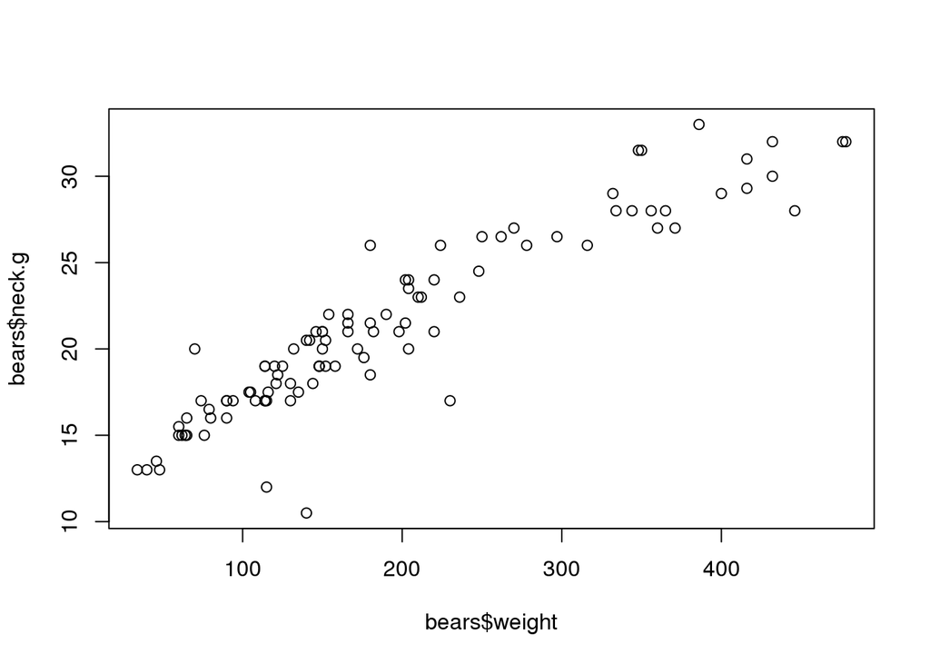

```r
plot(bears$weight, bears$neck.g)
```

### Weight vs. Chest Circumference

For the final graph, I plotted weight versus the chest circumference of a bear. Similar to the previous graph, there is a moderatly linear relationship between the two dimensions.

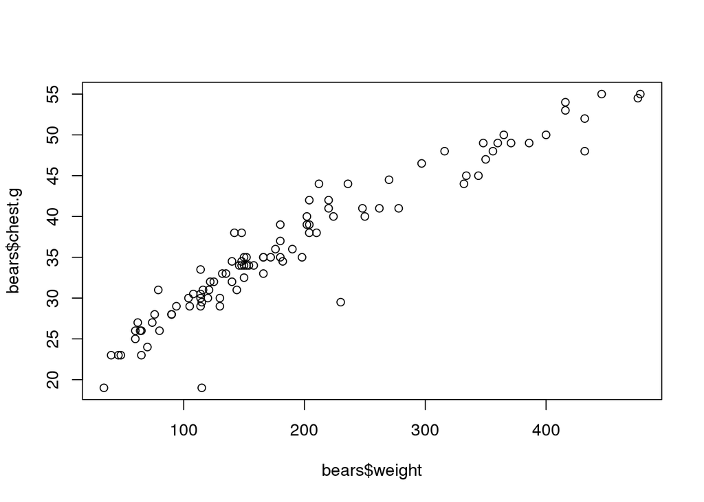

```r
plot(bears$weight, bears$chest.g)
```